# Лабораторная работа №8

Поиск файлов. Перенаправление ввода-вывода. Просмотр запущенных процессов

Автор

принадлежность

Юсупова Амина Руслановна

Российский университет дружбы народов

# Цели и задачи лабораторной работы

## Цель работы

Ознакомление с инструментами поиска файлов и фильтрации текстовых данных. Приобретение практических навыков: по управлению процессами (и заданиями), по проверке использования диска и обслуживанию файловых систем.

# Выполнение лабораторной работы

## Запись содержимого каталогов в файл

- `ls /etc > file.txt` – список файлов `/etc` записан в `file.txt`
- `ls ~ >> file.txt` – список домашнего каталога добавлен в конец того же файла

[figure not shown]

Создание file.txt и добавление содержимого домашнего каталога

## Отбор файлов с расширением `.conf`

- `grep '\.conf$' file.txt` – вывод строк, оканчивающихся на `.conf`
- `grep '\.conf$' file.txt > conf.txt` – сохранение результата в `conf.txt`

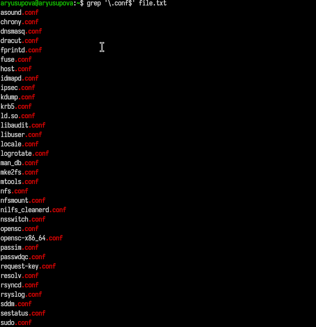

Вывод имён файлов с расширением .conf

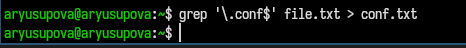

Сохранение отфильтрованных имён в conf.txt

## Поиск файлов в домашнем каталоге, начинающихся с `c`

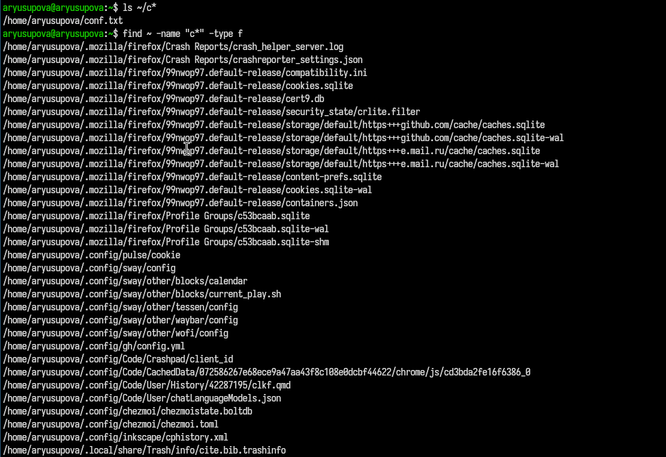

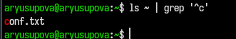

## Постраничный вывод имён файлов из `/etc`, начинающихся с `h`

`ls /etc/h* | less`

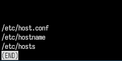

Постраничный вывод файлов из /etc, начинающихся на h

## Запуск фонового процесса для записи имён файлов с префиксом `log`

`find / -name "log*" -type f > ~/logfile 2>/dev/null &`

Поиск всех файлов, имена которых начинаются с `log`, с подавлением ошибок.

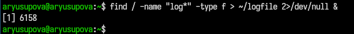

Запуск фонового процесса find

## Удаление файла ~/logfile

`rm ~/logfile`

Процесс `find` завершился с кодом 1 (сообщение о завершении).

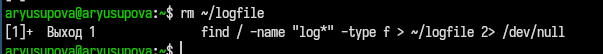

Удаление файла logfile

## Запуск редактора gedit в фоновом режиме

`gedit &`

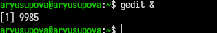

Запуск gedit в фоне

## Определение идентификатора процесса gedit

- `ps aux | grep gedit | grep -v grep`
- `pgrep gedit`
- `pidof gedit`
- `pstree -p | grep gedit`

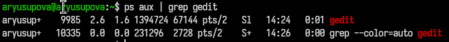

Определение PID gedit через ps и grep

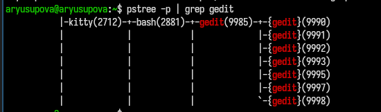

Дерево процессов с gedit (pstree)

## Завершение процесса gedit

- Изучена справка `man kill`
- `killall gedit` – завершение всех процессов с именем `gedit`

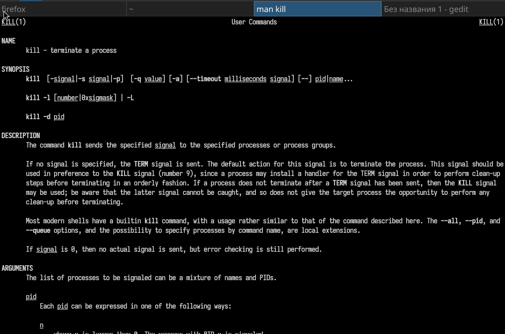

Справка man kill

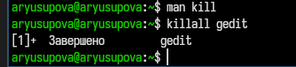

Завершение процесса gedit командой killall

## Выполнение команд `df` и `du`

- `df -h` – использование дискового пространства в удобочитаемом виде
- `du -sh ~` – размер домашнего каталога

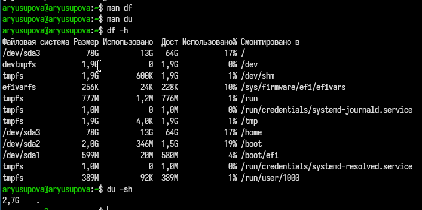

Результат выполнения df и du

## Вывод всех директорий в домашнем каталоге с помощью `find`

`find ~ -type d` – все поддиректории (включая вложенные)  
`find ~ -maxdepth 1 -type d` – только директории первого уровня

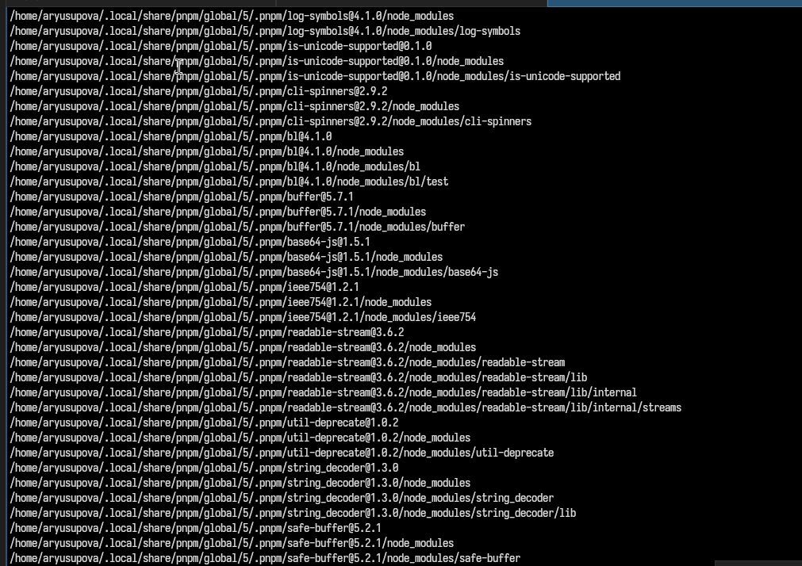

Вывод директорий в домашнем каталоге

# Выводы по проделанной работе

## Выводы

В ходе работы приобретены практические навыки:

- перенаправления потоков ввода-вывода (`>`, `>>`);
- использования конвейеров (`|`) для фильтрации данных;
- поиска файлов с помощью `find` и `grep`;
- управления фоновыми задачами и процессами (`&`, `jobs`, `kill`, `killall`);
- получения информации о дисковом пространстве (`df`, `du`).